# Assignment 4

Brittany Alexandra

2023-06-01

```r
library(tidyverse)
library(vegan)
library(MASS)
library(dplyr)
```

#### Q1. Create a metric multdimensional scaling.

> Using the distance matrix in powerDist-1.RData, create a metric multdimensional scaling. Plot using symbols/colors to represent Tariff and Group (the 3-level variable aggregating the acorn categories—these are in AcornInfo-1-1.csv). Make a second plot showing total use as bubble size, using color to represent Group. Summarize any trends or interesting features in these two plots.

> Plot using symbols/colors to represent Tariff and Group (the 3-level variable aggregating the acorn categories).

> Make a second plot showing total use as bubble size, using color to represent Group.

> Summarize any trends or interesting features in these two plots.

> What is the goodness of fit statistic from the mds? What can you tell from the fact the two goodness of fit measurements are the same? What does this statistic say about the adequacy of the representation?

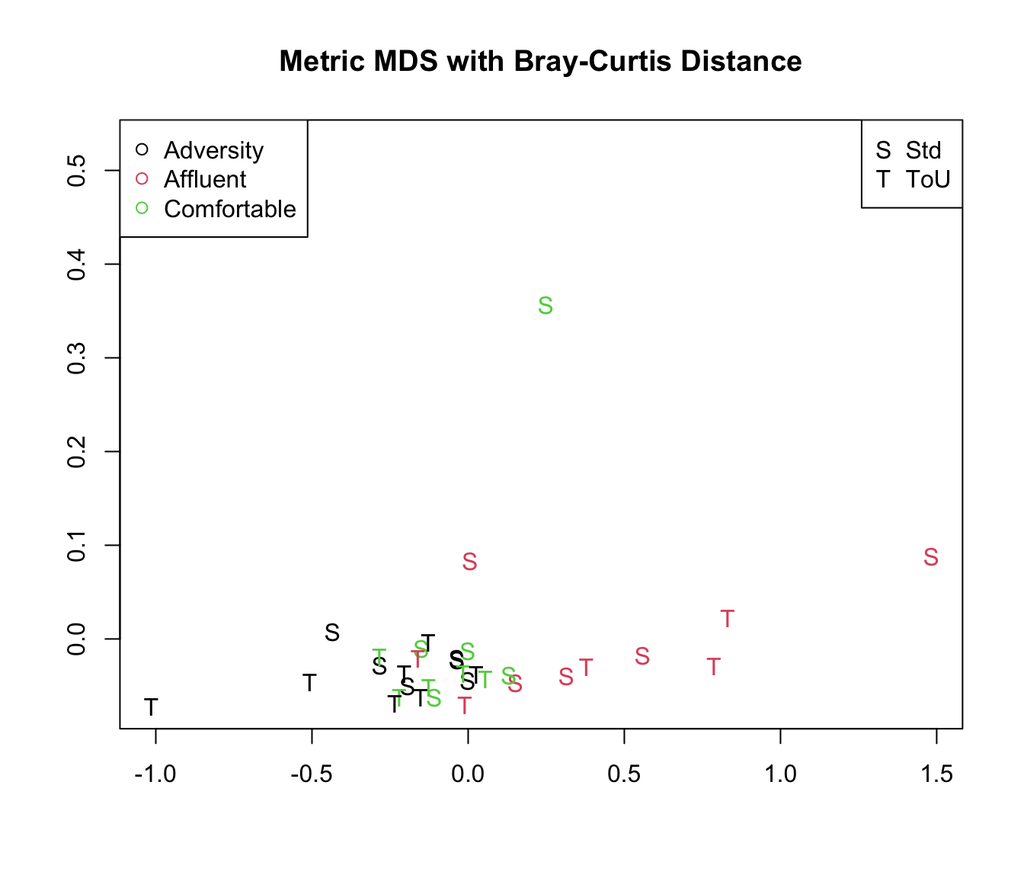

```r
#Metric MDS with Bray Curtis with colours/symbols to represent Tarrif
acorn.cmds <- cmdscale(powerDist,k=2, eig=TRUE)

plot(acorn.cmds$points,
     pch = substring(acorndata$Tariff, 1, 1),
     main="Metric MDS with Bray-Curtis Distance",
     xlab="",
     ylab='',
     col = factor(acorndata$Group))
legend("topright", levels(factor(acorndata$Tariff)), pch = c("S", "T"), col = 1)
legend("topleft", levels(factor(acorndata$Group)), col = 1:3, pch = 1)
```

```r
#Goodness of fit
acorn.cmds$GOF
```

```
## [1] 0.9753842 0.9753842
```

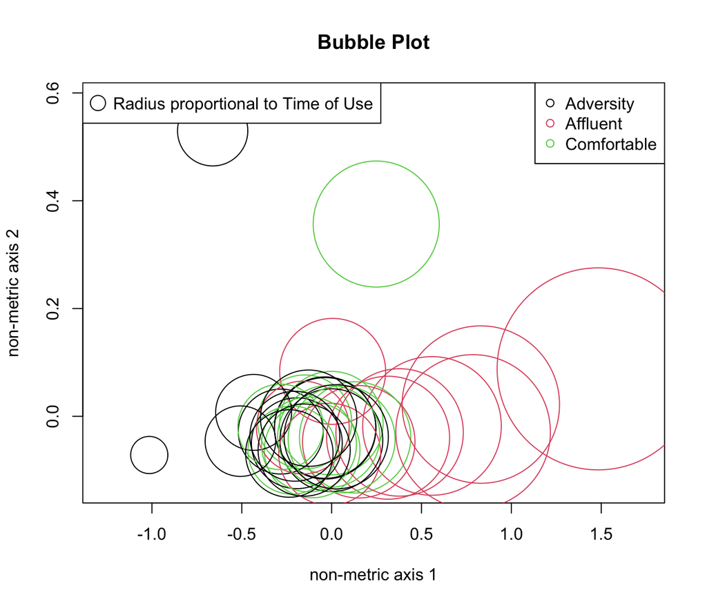

```r
#Bubble plot with colour representing group
##non jmetric mds
symbols(acorn.cmds$points, circles= acorndata$TotalUse,
        xlab="non-metric axis 1",
        ylab='non-metric axis 2',
        fg = as.factor(acorndata$Group),
        main="Bubble Plot")
legend("topleft", pch=1, pt.cex=2, legend="Radius proportional to Time of Use")
legend("topright", levels(factor(acorndata$Group)), col = 1:3, pch = 1)
```

BUBBLE PLOT The MDS plot reveals a cluster of Adverse, Comfortable, and Affluent socioeconomic groups positioned around the center. These groups are represented by bubbles of approximately equal size, suggesting a relative similarity to other groups in the MDS space.

The Affluent group shows a greater dispersion towards the right side of the X-axis. The bubbles representing this group increase in size as they move further along the X-axis, indicating higher values of Total Use. The Affluent group exhibits a trend of increasing usage as it progresses from 0 to 1.5 along the non-metric X-axis.

The Comfortable group is also centered around the middle of the non-metric X-axis at 0, with a slight dispersion towards a higher position along the Y-axis at 0.4. However, there seems to be only one bubble at this particular Y-axis height. The bubbles representing the Comfortable group are generally similar in size, indicating similar levels of total usage.

##### Q2. Create a dendrogram using complete linkage.

> Plot the dendrogram, labeling the leaves with the category they represent.

> Cut the dendrogram so four groups are created–show this on the plot.

> Make a table of these four groups and the three aggregated socio economic groups, and a separate table of the dendrogram groups and electricity tariff types.

> Are the dendrogram groups associated with either the socio economic group or tariff? Do not perform a test, but summarize any trends in your› tables.

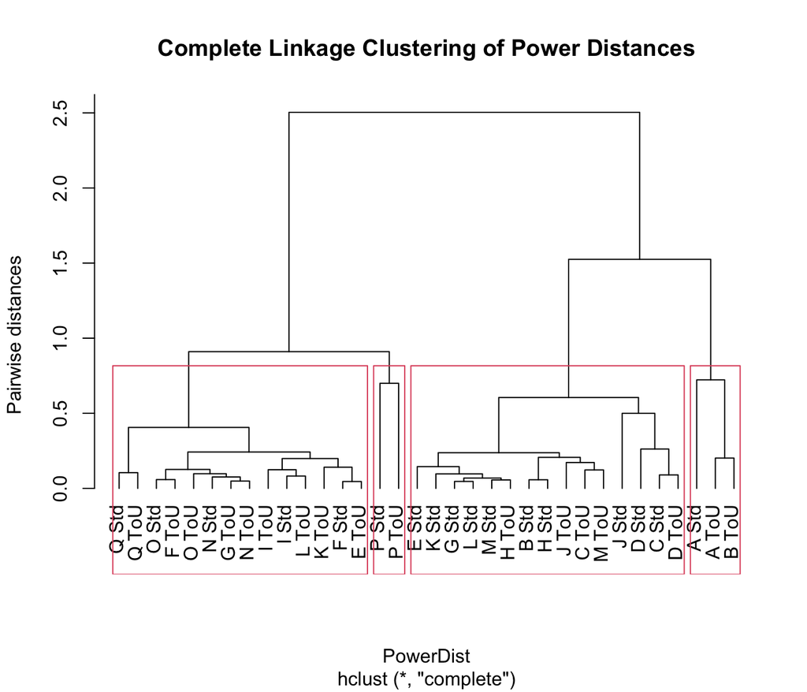

```r
#Hierachel clusterting
# Labeling the leaves with what they represent
# Cut the dendrogram so four groups are created–show this on the plot.
hclust(powerDist)->powerComplete #default is complete linkage
plot(powerComplete, hang = -1,
     main = "Complete Linkage Clustering of Power Distances",
     ylab = "Pairwise distances",
     xlab = "PowerDist")
rect.hclust(powerComplete, k=4)
```

```r
# Make a table of the dendrogram groups and electricity tariff types
cluster <- cutree(powerComplete, k = 4)
table(cluster, acorndata$Tariff)
```

```
##
## cluster Std ToU
##       1   1   2
##       2  10   5
##       3   5   9
##       4   1   1
```

```r
# Create a table of the four groups and the three aggregated socio-economic groups
table(cluster, acorndata$Group)
```

```
##
## cluster Adversity Affluent Comfortable
##       1         0        3           0
##       2         4        6           5
##       3         8        1           5
##       4         2        0           0
```

```r
#tells us what each of the groups belong to
cutree(powerComplete, k =4) -> clustervec
clustervec
```

```
## A Std B Std C Std D Std E Std F Std G Std H Std I Std J Std K Std L Std M Std
##     1     2     2     2     2     3     2     2     3     2     2     2     2
## N Std O Std P Std Q Std A ToU B ToU C ToU D ToU E ToU F ToU G ToU H ToU I ToU
##     3     3     4     3     1     1     2     2     3     3     3     2     3
## J ToU K ToU L ToU M ToU N ToU O ToU P ToU Q ToU
##     2     3     3     2     3     3     4     3
```

Dendrogram Groups and Socioeconomic Groups:

Our two smaller clusters; Cluster 1 and Cluster 4, are just from one socioeconomic class. Cluster 1 is a cluster of three Affluent groups, while cluster four is a cluster of two Adverse groups. Therefore there is a strong association between Cluster 1 and Affluent socioeconomic groups, and a strong association be Cluster 4 and Adverse socioeconomic groups.

Cluster 2 and 3 have a mixture of socioeconomic groups, with cluster 2 being relatively evenly distributed across Adverse, Affluent, and Comfortable. In contrast, 57% (8/14) of the groups in cluster 3 are from the Adverse socioeconomic groups, 35% are groups of Comfortable socioeconomic groups, while only 7% (1/14) of the cluster contains Affuent groups. Thereby indicating Cluster 3 is more representative of Adverse socioeconomic group and there is a weak relationship.

Dendrogram Groups and Tariff Types:

Cluster 4 is evenly distributed across the Standard / Time of Use Tariffs. Cluster 1,2, and 3 display a slight bias in the groups. Cluster 1 has one group of of Standard Tariffs, and two groups of Time of Use Tariffs; although this is a small discrepancy, that is 50% of of the ToU Tariff. This indicates a weak association with the Tou Tariff. Similarly, Cluster 2 has 10 groups of the Standard Tariff, while the Time of Use Tariff contains 50% of that with 5 groups indicating a moderate association with Std Tariff. Although its not super pronounced, if it really had nothing to do with the type, we’d expect it to be equally distributed across the clusters. Cluster 3 has 9 groups of the Time of Use Tariff, and 5 groups of the Standard Tariff, indicating a moderate association with the ToU Tariff.

#### Q3. Do a permanova based on the euclidian distance

> What are your conclusions?

```r
mod2 <- adonis(comfdata[,5:52]~comfdata[,4], permutations = 999, method = "euc")
```

```
## 'adonis' will be deprecated: use 'adonis2' instead
```

```r
mod2$aov.tab
```

```
## Permutation: free
## Number of permutations: 999
##
## Terms added sequentially (first to last)
##
##                Df SumsOfSqs MeanSqs F.Model      R2 Pr(>F)
## comfdata[, 4]   1      2.71  2.7080  2.4394 0.00381  0.091 .
## Residuals     638    708.24  1.1101         0.99619
## Total         639    710.95                 1.00000
## ---
## Signif. codes:  0 '***' 0.001 '**' 0.01 '*' 0.05 '.' 0.1 ' ' 1
```

#### Q4.

> Perform k-means clustering of the profiles from the comfortable households. Make graphs of the within group sum of squares, and the C-H index. Select a number of clusters, referring to featrues of the plots to justify your choice. Create tables of the cluster memberships and the detailed acorn categories, and of the cluster memberships and tariff. Are there any associations? Assess qualitatively; a chi-squared test would be appropriate here, but you need not perform one.

```r
comfort1 <- comfdata[,5:52]
kmod <- kmeans(comfort1, centers = 3, nstart=5)
names(kmod)
```

```
## [1] "cluster"      "centers"      "totss"        "withinss"     "tot.withinss"
## [6] "betweenss"    "size"         "iter"         "ifault"
```

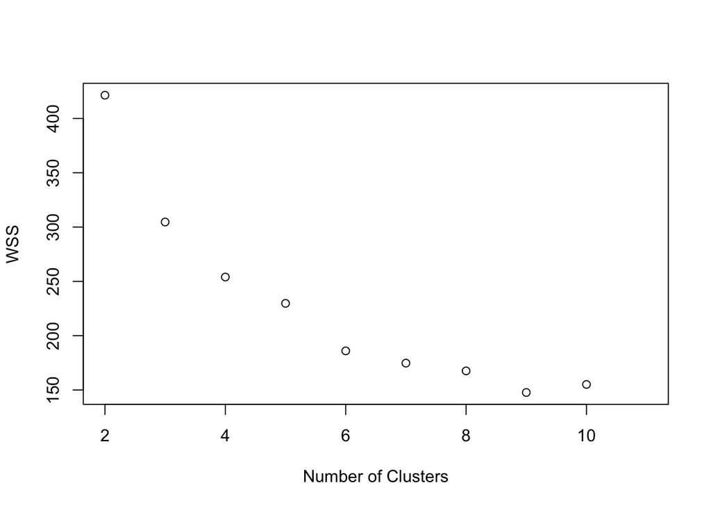

```r
#Number of clusters
WSS<-rep(NA,10)
for(i in 2:10){
WSS[i-1]<-kmeans(comfort1, centers=i, nstart=5)$tot.withinss
}
plot(2:11, WSS, xlab="Number of Clusters")
```

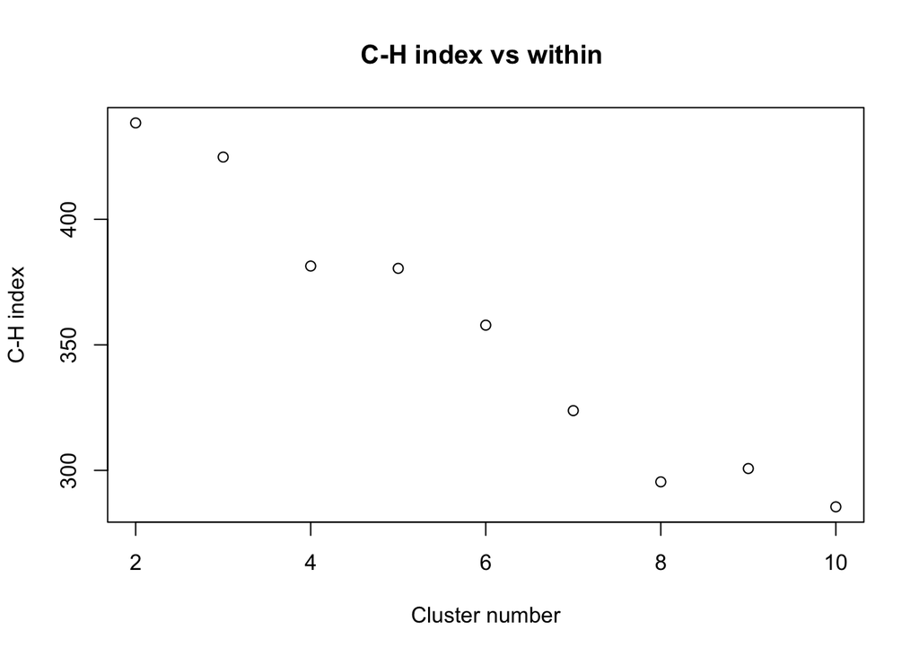

```r
#C-H index vs within
CH <- rep(NA, 9)
for(i in 2:10){kmod<-kmeans(comfort1, centers = i, nstart = 10)
CH[i-1]<-(kmod$betweenss/(i-1))/(kmod$tot.withinss/(nrow(comfort1)-i))}
plot(2:10,CH, xlab= "Cluster number", ylab="C-H index", main = "C-H index vs within ")
```

```r
kmod_chosen <- kmeans(comfort1, centers = 2, nstart = 10)

table(as.vector(kmod_chosen$cluster), as.vector(comfdata$ACORN))
```

```
##
##     ACORN-F ACORN-G ACORN-H ACORN-I ACORN-J
##   1      71      27      63       6      21
##   2     219      71     110      15      37
```

```r
table(as.vector(kmod_chosen$cluster), as.vector(comfdata$TARIFF))
```

```
##
##     Std ToU
##   1 104  84
##   2 216 236
```

```r
cluster_tariff_table <- table(as.vector(kmod_chosen$cluster), as.vector(comfdata$TARIFF))
chisq.test(cluster_tariff_table)
```

```
##
##  Pearson's Chi-squared test with Yates' continuity correction
##
## data:  cluster_tariff_table
## X-squared = 2.7189, df = 1, p-value = 0.09917
```

Cluster Memberships and Tariff: Cluster 1 has a higher proportion of households with the Standard (Std) tariff, while Cluster 2 has a higher proportion of households with the Time of Use (ToU) tariff.

However, from the Chisq test we have a insignificant P-value of 0.099 indicating the observed data is likely to have occurred from chance alone. We fail to reject the null hypothesis and conclude that there is no significant association or difference between the clusters in the Tariff and Acorn Groups based on the available evidence. Based on these observations, there does not appear to be an association between cluster memberships and both the detailed Acorn categories and the Tariff.